# Week 6: Fitting Logistic Growth Curves to Data

EFB 370 - Spring 2022

Nate Wehr and Elie Gurarie

2022-03-03

# Loading and exploring Paramecium data

Data on paramecium growth in a dish in a lab is in a file called `paramecium.csv` - available on Blackboard or at this link. Download the data and load it into R:

```r
p <- read.csv("paramecium.csv")
```

Look at the columns in this data:

```r
head(p)
```

```
##               Species Day         Nt       Nt1        dN         r
## 1 Paramecium caudatum   2   5.849284        NA        NA        NA
## 2 Paramecium caudatum   3  13.672890  5.849284  7.823607 1.3375324
## 3 Paramecium caudatum   4         NA 13.672890        NA        NA
## 4 Paramecium caudatum   5  35.697880        NA        NA        NA
## 5 Paramecium caudatum   6  73.947840 35.697880 38.249959 1.0714910
## 6 Paramecium caudatum   7 103.855191 73.947840 29.907352 0.4044385
```

What do the following commands do?

```r
nrow(p)
ncol(p)
dim(p)
names(p)
```

These data contain growth rates of paramecium (unicellular ciliates) raised in a petri dish with limited resources.

The columns are: `Species`, `Day` of experiment, `Nt` - quantity of paramecium now, `Nt1` - quantity 1 time step ago $\Delta N_{t-1}$, and $r$ - per-capita growth rate, i.e. $\Delta N_t/N_t$.

# Fit Method I: By Hand

Here’s, we’re going to try to guess the values of $r_0$, $K$ and $N_0$ by fitting a curve to the data by eye. The function for logistic growth - meaning the actual population against time - is:
$$N(t) = {K \over 1+\left({K- N_0 \over N_0}\right) e^{-r_0 t}}$$
This function is written in R as follows:

```r
N.logistic <- function(x, N0, K, r0) K/(1 + ((K - N0)/N0)*exp(-r0*x))
```

This code just says we’re creating a new function called `N.logistic()` which takes as arguments `x` (time), and three parameters and returns the predicted population.

YOU DO NOT NEED TO KNOW HOW TO CREATE A FUNCTION! Just open the script file `logisticfitscript.R`. It is posted on Blackboard or at this link. It contains just the following code:

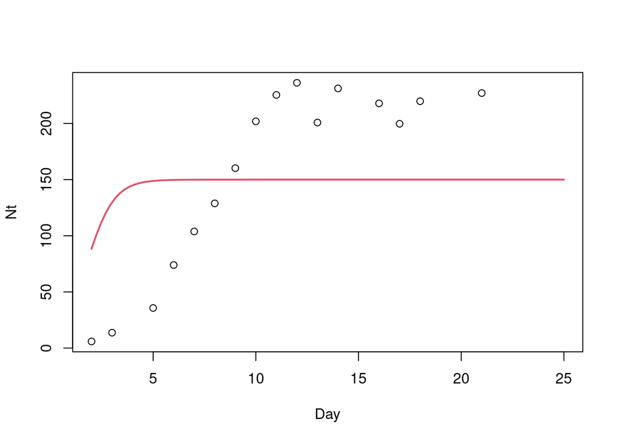

```r
p <- read.csv("paramecium.csv")
N.logistic <- function(x, N0, K, r0) K/(1 + ((K - N0)/N0)*exp(-r0*x))

# try different values!
N0 <- 10
K <- 150
r0 <- 1.5
plot(Nt~Day, data = p)
curve(N.logistic(x, N0, K, r0), add = TRUE, col = 2, lwd = 2)
```

The initial values guessed for `N0`, `K`, and `r0` are not very good. How close can you get to a nice fit of the curve? What is yuour best “by hand” guess of the parameters?

# Fit method II: Using $r(N)$

## Plotting N, dN and r

Lets plot the three figures we talked about in class: $N$ as a function of time, $\Delta N$ as a function of $N$, and $r$ as a function of $N$

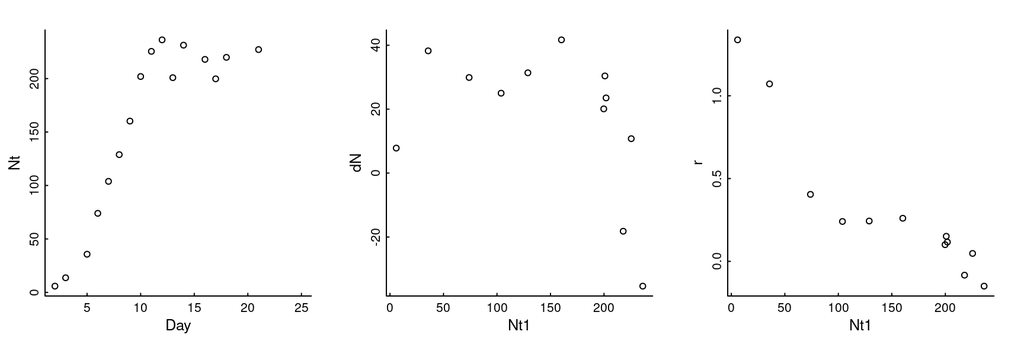

```r
plot(Nt~Day, data = p)
plot(dN~Nt1, data = p)
plot(r~Nt1, data = p)
```

These roughly show the patterns we expect of logistic regression.

## Linear model of R

One form of the logistic growth model simply says that:

$$r(N) = r_0 - {r_0 \over K} N$$

So if we do a straightforward linear regression, we can estimate both $r$ and $K$:

```r
lm(r ~ Nt1, data = p)
```

```
##
## Call:
## lm(formula = r ~ Nt1, data = p)
##
## Coefficients:
## (Intercept)          Nt1
##    1.088436    -0.005205
```

This suggests that r0 is roughly 1.09. We write:
$$\widehat{r_0} = 1.09$$

What does the slope tell us? Well - we can convert that to a carrying capacity, since:
$$\beta = -r_0/K.$$

Solving for $\widehat{K}$ we get:
$$\widehat{K} = 1.088 / 0.0052 = 209.1$$

## Check the fit

Is this estimate any good? Try putting these numbers into the fitting code:

```r
N0 <- 10
K <- 209
r0 <- 1.088
plot(Nt~Day, data = p)
curve(N.logistic(x, N0, K, r0), add = TRUE, col = 2, lwd = 2)
```

[output not shown]

We need to adjust $N_0$ - but otherwise not too bad.

## Standard errors

```r
r.lm <- lm(r ~ Day, data = p)
summary(r.lm)
```

```
##
## Call:
## lm(formula = r ~ Day, data = p)
##
## Residuals:
##     Min      1Q  Median      3Q     Max
## -0.2863 -0.2029 -0.1309  0.1823  0.4068
##
## Coefficients:
##             Estimate Std. Error t value Pr(>|t|)
## (Intercept)  1.17289    0.21861   5.365 0.000317 ***
## Day         -0.08073    0.01904  -4.240 0.001716 **
## ---
## Signif. codes:  0 '***' 0.001 '**' 0.01 '*' 0.05 '.' 0.1 ' ' 1
##
## Residual standard error: 0.2803 on 10 degrees of freedom
##   (12 observations deleted due to missingness)
## Multiple R-squared:  0.6426, Adjusted R-squared:  0.6069
## F-statistic: 17.98 on 1 and 10 DF,  p-value: 0.001716
```

- hard to convert these to a standard error around $K$
- no way to obatin an estimate for $N_0$ from this model

# Fit Method III: Non-linear least squares

One method of fitting a curve is to use the “least squares” method, i.e. find the parameters for which the squared deviation of the data from the curve is minimized. This is an *optimization* problem that the computer solves numerically.

The function that does this in R is called `nls()`. It is “non-linear”, unlike the regression model above. To do this, we have to use our function for the solution of the logistic curve and provide initial values. But the basic syntax is similar in that the response is `Nt` and the predictor is the logistic function of time (`Day`), with the parameters to be estimated following that `Day`. And the formula symbol is always `~`. Also - you have to help the computer find the optimum solution with some reasonable starting values - `start = list(...)`.

Anyways, the script to do this is `logisticfitscript2.R` - it is posted on Blackboard or at this link.

```r
p <- read.csv("paramecium.csv")
N.logistic <- function(x, N0, K, r0) K/(1 + ((K - N0)/N0)*exp(-r0*x))

nls(Nt ~ N.logistic(Day, N0, K, r0), data = p,
    start = list(N0 = 1, K = 200, r0 = 1.75))
```

```
## Nonlinear regression model
##   model: Nt ~ N.logistic(Day, N0, K, r0)
##    data: p
##       N0        K       r0
##   1.3087 222.3642   0.7075
##  residual sum-of-squares: 2172
##
## Number of iterations to convergence: 11
## Achieved convergence tolerance: 3.067e-06
```

As usual, we can save the results to an object and get a summary table with the fits:

```r
summary(nls(Nt ~ N.logistic(Day, N0, K, r0), data = p,
    start = list(N0 = 1, K = 100, r0 = 1)))
```

```
##
## Formula: Nt ~ N.logistic(Day, N0, K, r0)
##
## Parameters:
##     Estimate Std. Error t value Pr(>|t|)
## N0   1.30871    0.85196   1.536    0.148
## K  222.36417    5.22413  42.565  2.4e-15 ***
## r0   0.70747    0.09028   7.836  2.8e-06 ***
## ---
## Signif. codes:  0 '***' 0.001 '**' 0.01 '*' 0.05 '.' 0.1 ' ' 1
##
## Residual standard error: 12.92 on 13 degrees of freedom
##
## Number of iterations to convergence: 11
## Achieved convergence tolerance: 3.059e-06
##   (8 observations deleted due to missingness)
```

# Additional homework problem 4

> 1. Report the estimates of a fitted logistic curve to the Paramecium data, with confidence intervals.
> 2. Produce a plot of the fitted curve on top of the paramecium growth data.
> 3. *Extra Credit:* *Estimate the parameters of logistic growth with the BC Sea Otter data. In particular: What might the carrying capacity of sea otters in BC be?*